# Trend Detection

Edgar Derricho

2024-11-16

# Introduction

Trend detection is a crucial part of time series modeling. The objective of this project is to create a trend detection model that can rival common trend detection techniques.

# Problem Statement and Methdology

**Research Question:** Can we use the difference of prices in a five day period to detect the trend and the “strength” of the trend of the price?

For us to do this, we must define a **trend** and the **strength** of a trend. We will use the cascading question method.

- Q1: What is a **trend**?
- A1: A **trend** is a pattern in a value.
  - Q2: What is a **pattern** in the context of our research question?
  - A2: A **pattern** is a line that shows a clear change in price (up or down)
    - Q3: How (mathematically) will these **patterns** be identified in our model?
    - A3: We will use an n-day sum of slope to detect the **pattern**.

**Definition:** A **pattern/trend** will be as follows:
$$\sum^{n}_{i=1}\frac{y_{n+1}-y_{n}}{n}$$
To account for the relative change in price during our period $n$, we will normalize the price by dividing the sum of differences by the standard deviation, therefore:
$$\frac{\sum^{}_{}\frac{y_{n+1}-y_{n}}{n}}{\sigma(y_1,..,y_n)}=\tau$$

We will refer to this number as $\tau$. Intuitively, the further away $\tau$ is from zero, the **stronger** the trend is.

# Hypothesis Test

We will use a hypothesis test to asses the reliability of our trend detection model:  
$H_{0}: \tau=0$ - there is no trend in the data  
$H_{a}: \tau \neq 0$ - there exists a trend in the data

We must have a statistical test to show the significance of our value. We know that the differences of prices constitute a normal distribution and we are searching for the statistical significance of the difference of means. Therefore, we can use the following formula for the t-test:
$$t =
\frac{\tau-\tau_0}{s/\sqrt{n}}= \frac{\tau}{s/\sqrt{n}}$$
With the test statistic, we can retrieve a p-value.

# Function

We will use our function to asses the validity of the trend in the data. We will also run a linear regression model and observe the p-value of the coefficient of regression. We will plot the data along with the window that we are looking for. By plotting an area greater than our window, we can see if the trend is a part of a true trend. The wider our window, the more we can see if our trend is true.

```r
# Gather the Data
apple_df <- getSymbols('AAPL',src='yahoo',auto.assign = F)

# Tau Function
tau.fun <- function(data,min,max,window=5,alpha=0.05,output=0){
  # -------------- Tau Calculation ------------------------------------
  #graph_data <- data[(min-window):(max+window)] # the window is for graphing
  data <- data[min:max]
  n <- max - min # Calculate n
  difference <- diff(data[1:n]) # Calculate Difference
  difference <- difference[2:length(difference)] # Eliminate NA
  sd_difference <- sd(difference)
  sum_difference <- mean(difference)/sd(data) # Sum of Difference (Tau)
  t <- sum_difference/(sd(difference)/sqrt(n-1)) # t-value
  p_value <- 2 * pt(q=abs(t),df=n-2,lower.tail = F) # p-value
  # ------------------- Linear Regression Model ------------------------
  index <- c(1:length(data))
  mod <- lm(data ~ index)
  coef <- mod$coefficients[2]
  sum <- summary(mod)
  reg_pVal <- sum$coefficients[2,4]
  tau_significance <- ifelse(p_value > alpha,"fail to reject","reject")
  reg_significance <- ifelse(reg_pVal > alpha,"fail to reject","reject")
  direction_tau <- ifelse(sum_difference>0,"positive","negative")
  direction_reg <- ifelse(coef>0,"positive","negative")
  # ---------------- Data Frame of Results -----------------------------
  df <- data.frame(#data,
                   min,
                   max,
                   sum_difference,
                   sd_difference,
                   p_value,
                   coef,
                   reg_pVal,
                   tau_significance,
                   reg_significance,
                   direction_tau,
                   direction_reg)
  colnames(df) <- c(#"Price",
                    "Min",
                    "Max",
                    "Sum of Difference",
                    "St.Dev. of Difference",
                    "Tau p-value",
                    "Regression Coef",
                    "Regression p-value",
                    "Null Tau",
                    "Null Regression",
                    "Tau Direction",
                    "Regression Direction")

  # ------------------ Create the plot ------------------------------
  x <- c(1:length(data))

  # Change min and max for graph
  min <- window
  max <- length(data) - window-1
  mid <- (max - min)/2

  # Plot
  plot <- ggplot(data.frame(data), aes(x = x, y = data)) +
    geom_line(color = "blue", size = 1.2) +  # Line plot
    geom_rect(aes(xmin = min, xmax = max,   # Rectangle
                  ymin = -Inf, ymax = Inf),
              fill = "red", alpha = 0.01) + # Highlight color with transparency
    labs(title = "Highlight a Window in ggplot2") +
    theme_minimal()

  #print(plot) # Optional Print Plot

  # ---------------------- Model Output: ----------------------------------
  if(output == 1){
    cat("--------- Summary ---------","\n",
      "Tau p-value: ",p_value,"\n",
      "Regression p-value: ", reg_pVal,"\n",
      "----------- Diff ----------","\n",
      "Sum of Differences: ", sum_difference,"\n",
      "SD of Differences: ", sd_difference,"\n",
      "---------------------------")
  }
  return(df)
}

test <- tau.fun(apple_df$AAPL.Close,min = 6,max = 10)
kable(test, format = "html", table.attr = "style='width:50%;'") %>%
  kable_styling(bootstrap_options = c("striped", "hover", "condensed", "responsive"),
                    full_width = FALSE,
                    position = "center")
```

|  | Min | Max | Sum of Difference | St.Dev. of Difference | Tau p-value | Regression Coef | Regression p-value | Null Tau | Null Regression | Tau Direction | Regression Direction |
| --- | --- | --- | --- | --- | --- | --- | --- | --- | --- | --- | --- |
| index | 6 | 10 | 0.0292281 | 0.0756746 | 0.5723914 | -0.0100002 | 0.5183561 | fail to reject | fail to reject | positive | negative |

**Output of the Function:**  
- Minimum Index  
- Maximum Index  
- Sum of Difference ($\tau$)  
- Standard Deviation of Differences  
- Tau p-value  
- Regression Coefficient in the Same Window  
- Regression Coefficient p-value  
- Outcome of Hypothesis Test for $\tau$ - Outcome of Hypothesis Test for Regression Coefficient $\beta$  
- Direction of $\tau$  
- Direction of Regression

# Function Implimentation

Now, we will run the above function through the data set with $n=10$ where we use a rolling $\tau$ and $\beta$.

```r
n <- 10# Window of regression
min <- 1 # Minimum Index
max <- 500 # Maximum index
results <- data.frame()
data <- apple_df$AAPL.Close
for(i in min:max){
  left <- i
  right <- i + n
  res <- tau.fun(data,left,right,window=0)
  results <- rbind(results,res)
  if(i == max - n){ # Break for last n values
    break
  }
}

#graph_data <- data.frame(c(min:max),apple_df$AAPL.Close[min:max])

kable(head(results), format = "html", table.attr = "style='width:50%;'") %>%
  kable_styling(bootstrap_options = c("striped", "hover", "condensed", "responsive"),
                    full_width = FALSE,
                    position = "center")
```

[output not shown]

# Tao-Test vs Linear Regression Coef. $\beta$

Let us Graph the Results

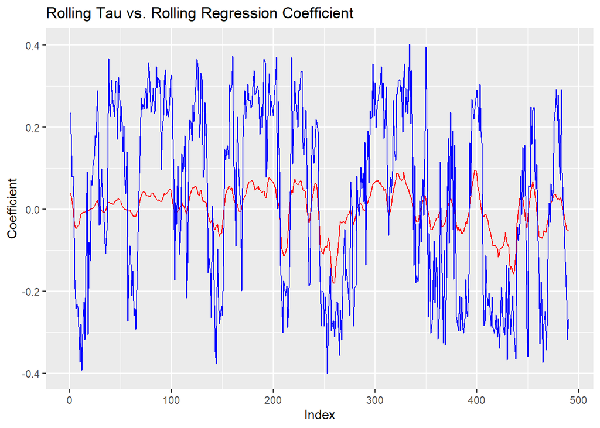

```r
# Tau p-value vs Beta p-value
x<-c(1:length(results$Min))
ggplot(data = results)+
  geom_line(aes(x=x,y=results$`Regression Coef`),col="red")+
  geom_line(aes(x=x,y=results$`Sum of Difference`),col="blue")+
  labs(
    title = "Rolling Tau vs. Rolling Regression Coefficient",
    x = "Index",
    y = "Coefficient"
  )
```

# Observations and Conclusion

When observing $\tau$ and $\beta$, we see that generally, when $\tau$ is positive, $\beta$ is also positive. However, $\tau$ is much more sensitive to the trend than the regression coefficient $\beta$. Because of this, we will use $\tau$ in an ensemble method with linear regression to detect trends. Let us observe when both models have the same conclusion about their null hypotheses. Recall the null and alternative hypotheses of our $\tau$ test and the regression coefficient $\beta$.

Let us graph the instances where both tests suggest we either reject or fail to reject the null hypothesis.

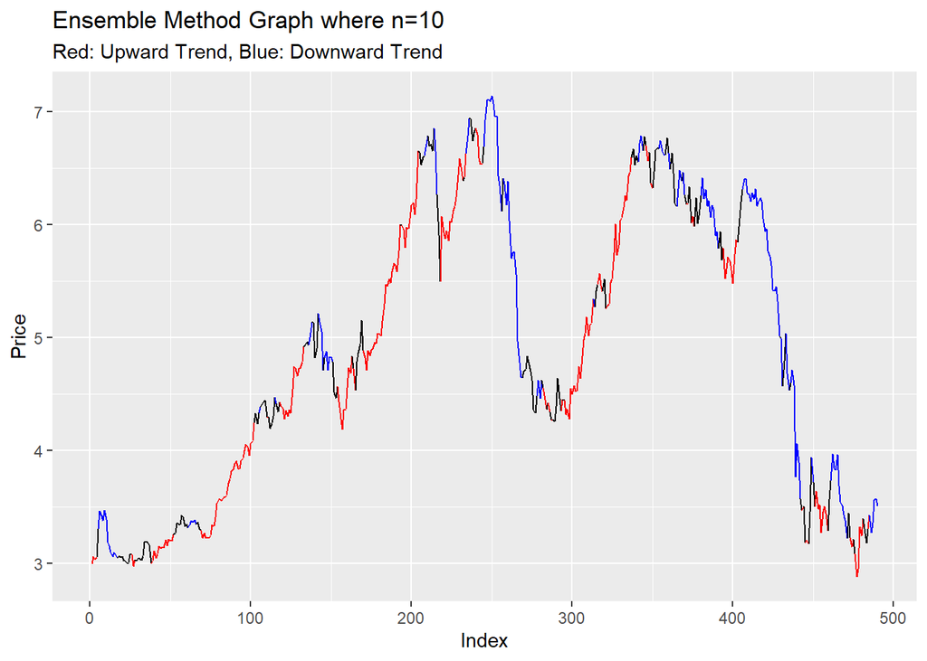

```r
# Put Indexes where both results are the same into a data frame
p_value_df <- data.frame(apple_df$AAPL.Close[min:(max-n)],
                         results$`Null Tau`[min:(max-n)],
                         results$`Null Regression`[min:(max-n)],
                         results$`Tau Direction`[min:(max-n)],
                         results$`Regression Direction`[min:(max-n)])

# ------------------------- Color Code Data -------------------------------------------
x <- c(1:length(p_value_df$AAPL.Close)) # X-values

# Color Group Ensemble
p_value_df$color_group_ensemble <- ifelse(p_value_df$results..Null.Tau. == p_value_df$results..Null.Regression., ifelse(p_value_df$results..Tau.Direction..min..max...n..==p_value_df$results..Regression.Direction..min..max...n..,ifelse(p_value_df$results..Tau.Direction..min..max...n..=="positive","red","blue"),"black"), "black") # Color the data

# Color Group Tau
p_value_df$color_group_tau <- ifelse(p_value_df$results..Null.Tau. == "reject", ifelse(p_value_df$results..Tau.Direction..min..max...n..=="positive","red","blue"), "black")

# Color Group Regression
p_value_df$color_group_reg <- ifelse(p_value_df$results..Null.Regression..min..max...n.. == "reject", ifelse(p_value_df$results..Regression.Direction..min..max...n..=="positive","red","blue"), "black")

# ---------------------------------- Plot Data -------------------------------------
# Plot Ensemble
ggplot(data = p_value_df)+
  geom_line(aes(x=x,y=p_value_df$AAPL.Close),color=p_value_df$color_group_ensemble)+
  labs(
    title = "Ensemble Method Graph where n=10",
    x = "Index",
    y = "Price",
    subtitle = "Red: Upward Trend, Blue: Downward Trend"
  )+
  theme(legend.position = "bottom")
```

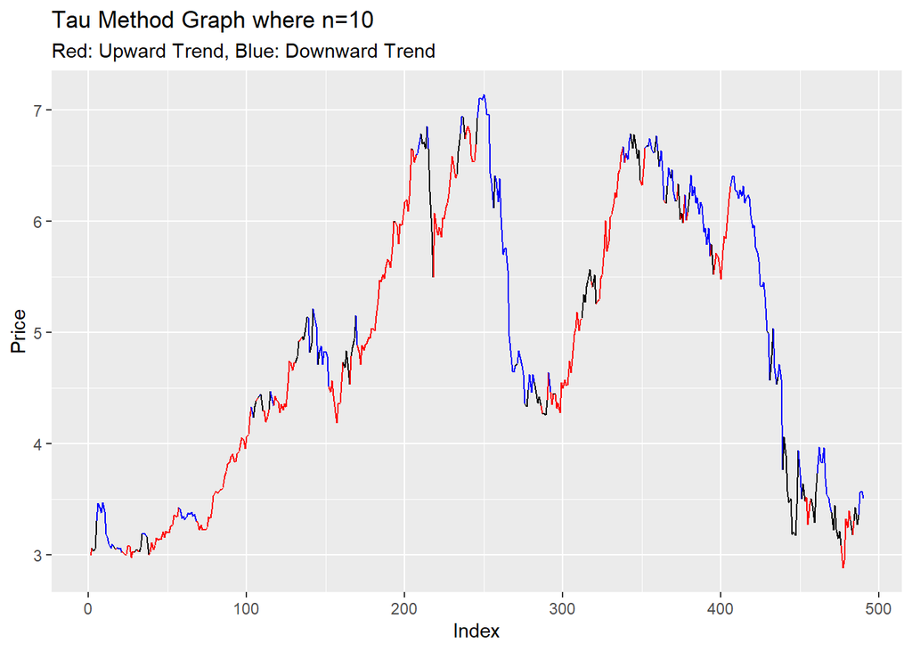

```r
# Plot Tau
ggplot(data = p_value_df)+
  geom_line(aes(x=x,y=p_value_df$AAPL.Close),color=p_value_df$color_group_tau)+
  labs(
    title = "Tau Method Graph where n=10",
    x = "Index",
    y = "Price",
    color = "Color Legend",
    subtitle = "Red: Upward Trend, Blue: Downward Trend"
  )
```

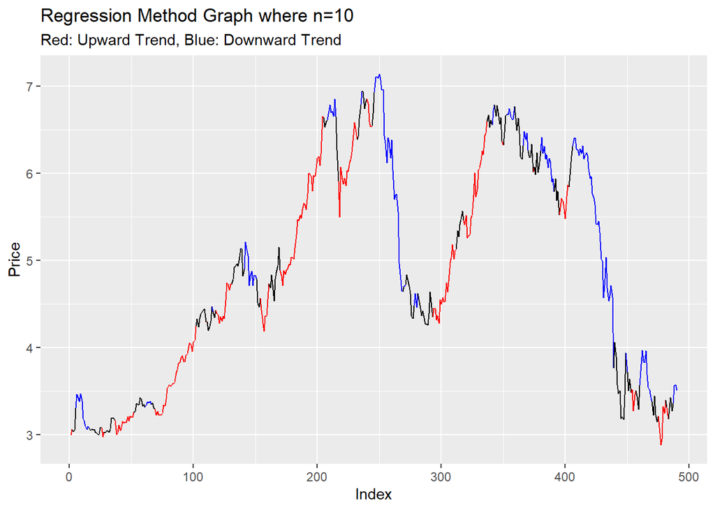

```r
# Plot Regression
ggplot(data = p_value_df)+
  geom_line(aes(x=x,y=p_value_df$AAPL.Close),color=p_value_df$color_group_reg)+
  labs(
    title = "Regression Method Graph where n=10",
    x = "Index",
    y = "Price",
    subtitle = "Red: Upward Trend, Blue: Downward Trend"
  )
```